# Allele frequency change and selection

Matheus Januario, Andressa Viol, and Daniel Rabosky

Jan 2024

# Learning objectives

1. Breeding effective population size
2. Mutation-drift equilibrium
3. Selection
4. The case of the peppered moths

First, we load our packages:

```r
library(evolved)
```

popgen_selection.R

# Introduction

We already saw in other popgen vignettes that due to sampling only, allele frequencies are predicted to change with time in a finite population – a process we call genetic drift. Still, many things *other than drift* also change allele frequency. We will work with them today.

# Breeding effective population size

Following Wright (1931), the breeding effective size is calculated as:

$$\begin{equation}
N_e = \frac{4N_m N_f}{N_m+N_f}
\end{equation}$$

# Mutation-drift equilibrium

# Selection

Using the function `NatSelSim()` (from `evolved`) you can explore how selection occurs in a bi-allelic gene of a diploid organism, given a set of arguments: `p0` is the initial frequency of the focal allele (labeled $A_1$ in the output plots), `w11` is the fitness of the homozygote for the focal allele, and `w12` is the heterozygote fitness. The function also requires the number of generations simulated (`n.gen`).

Do your results correspond to your hypotheses?

# The case of the peppered moths

For a long time, melanic individuals of *Biston betularia* (the peppered moth) were considered to be rare. The first dark morph was deposited in a museum only in 1811 (Berry, 1990), 53 years after the species was first described. The first live specimen was caught 37 years after that by R.S. Edleston in 1848. Only 16 years later, however, Edleston would say that the dark (a.k.a. *carbonaria*) morph was the most common morph that he caught in his garden (Berry, 1990).

At the time many hypotheses were drawn to explain this phenomenon (Cook & Turner, 2020), but a very good hypothesis is that light-colored morphs were able to camouflage easier in lichenous tree barks (see figure 1), while the dark morph was easily seen by birds on this background. However, after the industrial revolution, many of the lichen died, exposing the darker tree bark underneath and supposedly changing which morph was most visible to birds.

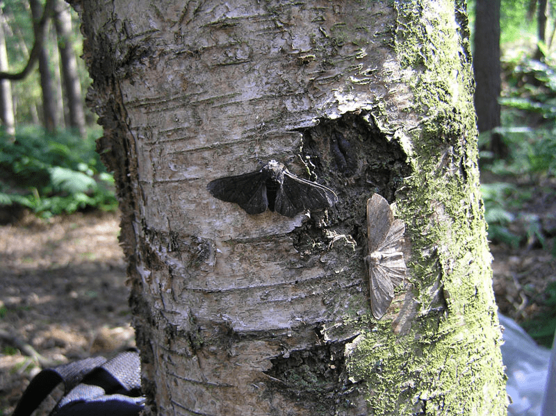

Light and carbonaria morphs of the peppered moth on the same lichenous tree. Image from wikicommons.

popgen_selection.R

Almost a century ago, J. B. S. Haldane performed some calculations on peppered moth morphs to estimate the selection coefficient ($s$) that natural populations face (Haldane, 1924). Below, you will use a similar approach to also estimate $s$, departing from the same data and assumptions that Haldane used.

Haldane made his estimate using analytic calculations, but we can approach his results by using a procedure similar to the one below:

1. Multiply the frequency of each genotype in the population by its relative fitness, obtaining the frequency of genotypes that will actually reproduce.
2. Get the new allele frequency *after* selection. Then, assume those genotypes mate randomly, which will lead to offspring genotypes that follow frequencies expected by HWE and the new allelic frequency (the one after selection).
3. Repeat steps I-II until selection for that characteristic is over (i.e., $s = 0$) or there is no genetic variation anymore. Note that this is no different than what the function `NatSelSim()` does “under its hood” (which you can check by typing the function name without the parenthesis in the R console).

We need some data to help us calculate our estimates. Drawing from the literature, Haldane assumed that the **carbonaria morph alelle had a frequency of roughly 1% in 1848 but that its frequency had increased to 99% after 50 generations**.

Taking Haldane’s assumptions for granted, and using the procedure explained above, we are going to estimate the intensity of selection favoring the dark morph. To do that:

**(1)** Assume that the *carbonaria* allele is dominant, and begin with the allele frequency given above for the *carbonaria* allele before the industrial revolution.

**(2)** Then, use step I-III above to compute the final frequency of the allele after 50 generations of selection. After each simulation, your value of $s$ will be fixed.

**(3)** Do many simulations across a range of relative fitness values for the light morph allele.

**(4)** Using the final $p$ frequencies from all simulations, you will generate a “profile plot”, where your x-axis should be the relative fitness of light morph, and your y-axis should be the final frequency of the carbonaria allele after 50 generations.

Since Haldane did his approximation, subsequent research has greatly improved our knowledge of peppered moth evolution. The fact that we have few good temporal records from the period in which melanic individuals were increasing in frequency obscures many details, but several possibilities were considered for the observed change, from linkage disequilibrium of melanic alleles to heterozygote advantage (Cook & Turner, 2020). Still, Haldane’s point is very clear: **selection can be really strong in natural populations!** However, even though the melanic morph had very high frequency at the early 20th century, this allele was *not* fixed. Influx of alleles via mating with migrants from elsewhere were not considered a good hypothesis at the time but, much later, DNA-based evidence in favor of that hypothesis was found (Cook & Turner, 2020). Are you surprised that natural populations, even in such “simple” scenarios, are *that* complex?

# References

Berry, R. J. (1990). Industrial melanism and peppered moths (Biston betularia (L.)). Biological Journal of the Linnean Society, 39(4), 301-322.

Cook, L. M., & Turner, J. R. (2020). Fifty per cent and all that: what Haldane actually said. Biological Journal of the Linnean Society, 129(3), 765-771.

Edleston, R. S., 1864. Amptydasis betularia. The Entomologist, 2: 150

Haldane JBS. 1924. A mathematical theory of natural and artificial selection. Transactions of the Cambridge Philosophical Society 23: 19–41.

Wright, S. (1931). Evolution in Mendelian populations. Genetics, 16(2), 97.